# Soccer Statistics

## About the data

- **date** - date of the match
- **home_team** - the name of the home team
- **away_team** - the name of the away team
- **home_score** - full-time home team score including extra time, not including penalty-shootouts
- **away_score** - full-time away team score including extra time, not including penalty-shootouts
- **tournament** - the name of the tournament
- **city** - the name of the city/town/administrative unit where the match was played
- **country** - the name of the country where the match was played
- **neutral** - TRUE/FALSE column indicating whether the match was played at a neutral venue

## Tableau Dashboard

Here is the link to tableau dashboard https://public.tableau.com/shared/GTKN4RGHT?:display_count=yes

### Loading the packages

```python
#importing all the neccessary packages
import pandas as pd
import numpy as np
import calendar
import matplotlib.pyplot as plt        # For plotting graphs
%matplotlib inline
from sklearn import tree
import warnings
from sklearn.ensemble import RandomForestClassifier
from sklearn.model_selection import train_test_split
from sklearn.model_selection import StratifiedKFold
from sklearn.metrics import precision_score, accuracy_score, confusion_matrix, recall_score
from sklearn.metrics import roc_curve
from sklearn.metrics import roc_auc_score
warnings.filterwarnings('ignore')
```

### Loading the dataset

```python
#loading the csv
df_football = pd.read_csv('results.csv')
```

```python
#number of records in dataset
df_football.shape
```

```
(39669, 9)
```

There are **39669** rows and **9** columns in our dataset

```python
#displaying the subset of data
df_football.head()
```

|  | date | home_team | away_team | home_score | away_score | tournament | city | country | neutral |
| --- | --- | --- | --- | --- | --- | --- | --- | --- | --- |
| 0 | 1872-11-30 | Scotland | England | 0 | 0 | Friendly | Glasgow | Scotland | False |
| 1 | 1873-03-08 | England | Scotland | 4 | 2 | Friendly | London | England | False |
| 2 | 1874-03-07 | Scotland | England | 2 | 1 | Friendly | Glasgow | Scotland | False |
| 3 | 1875-03-06 | England | Scotland | 2 | 2 | Friendly | London | England | False |
| 4 | 1876-03-04 | Scotland | England | 3 | 0 | Friendly | Glasgow | Scotland | False |

## Initial Analysis

### Checking the data types & missing values

```python
#displaying the datatypes
df_football.info()
```

```
<class 'pandas.core.frame.DataFrame'>
RangeIndex: 39669 entries, 0 to 39668
Data columns (total 9 columns):
date          39669 non-null object
home_team     39669 non-null object
away_team     39669 non-null object
home_score    39669 non-null int64
away_score    39669 non-null int64
tournament    39669 non-null object
city          39669 non-null object
country       39669 non-null object
neutral       39669 non-null bool
dtypes: bool(1), int64(2), object(6)
memory usage: 2.5+ MB
```

#### Observation:

`date` variable is **string** data type and there are no missing values in our dataset

### Converting `date` column datatype `datetime`

```python
#converting datatype to int
df_football['date'] = pd.to_datetime(df_football['date'],format = '%Y-%m-%d')
```

```python
df_football.info()
```

```
<class 'pandas.core.frame.DataFrame'>
RangeIndex: 39669 entries, 0 to 39668
Data columns (total 9 columns):
date          39669 non-null datetime64[ns]
home_team     39669 non-null object
away_team     39669 non-null object
home_score    39669 non-null int64
away_score    39669 non-null int64
tournament    39669 non-null object
city          39669 non-null object
country       39669 non-null object
neutral       39669 non-null bool
dtypes: bool(1), datetime64[ns](1), int64(2), object(5)
memory usage: 2.5+ MB
```

### Duplicate records check

```python
#duplicate records check
sum(df_football.duplicated())
```

```
0
```

#### Observation:

There are no duplicates rows in the dataset

## Exploratory Data Analysis

### `Home team`

How many uniques teams in Home_team column ?

```python
#unique home teams
df_football['home_team'].nunique()
```

```
291
```

### `Away team`

How many uniques teams are in Away_team column?

```python
#unique away teams
df_football['away_team'].nunique()
```

```
289
```

### `Home score`

```python
#distribution of home score
df_football['home_score'].value_counts()
```

```
1     11712
0      9503
2      8792
3      4675
4      2408
5      1153
6       630
7       335
8       186
9       111
10       58
11       32
12       26
13       12
14       10
15        7
16        6
17        4
19        3
24        1
18        1
20        1
21        1
22        1
31        1
Name: home_score, dtype: int64
```

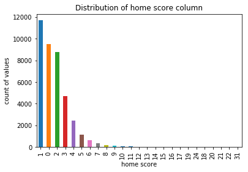

```python
df_football['home_score'].value_counts().plot.bar()
plt.title('Distribution of home score column')
plt.ylabel('count of values')
plt.xlabel('home score')
plt.show()
```

#### Observation:

Home teams have scored **1** goal in maximum number of matches

```python
#average of home score
print("Average of Home score:", round(df_football['home_score'].mean(),0))
```

```
Average of Home score: 2.0
```

### `Away Score`

```python
#distribution of away score
df_football['away_score'].value_counts()
```

```
0     14684
1     12812
2      6910
3      2977
4      1226
5       510
6       261
7       129
8        65
9        35
10       20
12        8
13        6
15        6
18        4
20        3
11        3
16        3
17        3
19        2
14        1
21        1
Name: away_score, dtype: int64
```

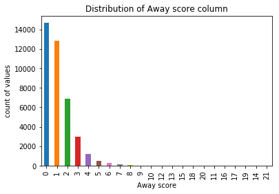

```python
df_football['away_score'].value_counts().plot.bar()
plt.title('Distribution of Away score column')
plt.ylabel('count of values')
plt.xlabel('Away score')
plt.show()
```

#### Observation:

Away teams have scored **0** goals in more than 14000 matches

```python
print("Average of Away score:", round(df_football['away_score'].mean(),0))
```

```
Average of Away score: 1.0
```

### `Tournament`

```python
#unique tournaments
df_football['tournament'].nunique()
```

```
102
```

### `City`

```python
#unique cities
df_football['tournament'].nunique()
```

```
102
```

### `Country`

```python
#unique countries
df_football['country'].nunique()
```

```
265
```

### `Neutral`

```python
df_football['neutral'].value_counts()
```

```
False    29848
True      9821
Name: neutral, dtype: int64
```

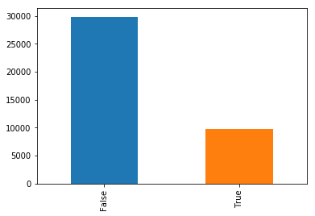

```python
df_football['neutral'].value_counts().plot.bar()
```

### Feature Engineering

Creating additional column `result` based `home_score` and `away_score`

if `home_score` > `away_score` , then `result` = **home**

if `home_score` < `away_score` , then `result` = **away**

if `home_score` = `away_score` , then `result` = **tie**

```python
#calculating result variable
def who_won(row):
    if row['home_score'] > row['away_score']:
        val = 'home'
    elif row['home_score'] < row['away_score']:
        val = 'away'
    else:
        val = 'tie'
    return val

df_football['result'] = df_football.apply(who_won, axis=1)
```

#### Test

```python
df_football.head()
```

|  | date | home_team | away_team | home_score | away_score | tournament | city | country | neutral | result |
| --- | --- | --- | --- | --- | --- | --- | --- | --- | --- | --- |
| 0 | 1872-11-30 | Scotland | England | 0 | 0 | Friendly | Glasgow | Scotland | False | tie |
| 1 | 1873-03-08 | England | Scotland | 4 | 2 | Friendly | London | England | False | home |
| 2 | 1874-03-07 | Scotland | England | 2 | 1 | Friendly | Glasgow | Scotland | False | home |
| 3 | 1875-03-06 | England | Scotland | 2 | 2 | Friendly | London | England | False | tie |
| 4 | 1876-03-04 | Scotland | England | 3 | 0 | Friendly | Glasgow | Scotland | False | home |

Extracting the `month` from `date` column

```python
#extracting month from date variable
df_football['month'] = df_football['date'].dt.month
df_football['month'] = df_football['month'].apply(lambda x: calendar.month_abbr[x])
```

```python
df_football['year'] = df_football['date'].dt.year
```

#### Test

```python
df_football.head()
```

|  | date | home_team | away_team | home_score | away_score | tournament | city | country | neutral | result | month | year |
| --- | --- | --- | --- | --- | --- | --- | --- | --- | --- | --- | --- | --- |
| 0 | 1872-11-30 | Scotland | England | 0 | 0 | Friendly | Glasgow | Scotland | False | tie | Nov | 1872 |
| 1 | 1873-03-08 | England | Scotland | 4 | 2 | Friendly | London | England | False | home | Mar | 1873 |
| 2 | 1874-03-07 | Scotland | England | 2 | 1 | Friendly | Glasgow | Scotland | False | home | Mar | 1874 |
| 3 | 1875-03-06 | England | Scotland | 2 | 2 | Friendly | London | England | False | tie | Mar | 1875 |
| 4 | 1876-03-04 | Scotland | England | 3 | 0 | Friendly | Glasgow | Scotland | False | home | Mar | 1876 |

### Bi-variate analysis

#### Which team played the most ?

#### Answer:

Sweden tops the list with **998** matches followed by England , Brazil and Argentina.

```python
#grouping teams
all_teams = df_football['home_team'].append(df_football['away_team'])
all_teams = pd.DataFrame(all_teams, columns = ['teams'])
all_teams.groupby('teams')['teams'].count().sort_values(ascending = False).head(10)
```

```
teams
Sweden            998
England           982
Brazil            957
Argentina         957
Germany           933
Hungary           912
Uruguay           865
Mexico            841
Korea Republic    837
France            819
Name: teams, dtype: int64
```

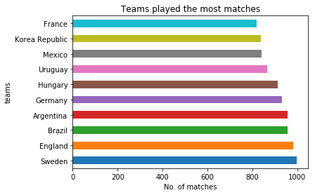

```python
#plotting teams and their matches
all_teams.groupby('teams')['teams'].count().sort_values(ascending = False).head(10).plot(kind= "barh", align = 'center')
plt.title('Teams played the most matches')
plt.xlabel('No. of matches')
plt.show()
```

### Trend of popularity of soccer over the time

```python
df_football.groupby('year')['home_team'].count().head(10)
```

```
year
1872    1
1873    1
1874    1
1875    1
1876    2
1877    2
1878    2
1879    3
1880    3
1881    3
Name: home_team, dtype: int64
```

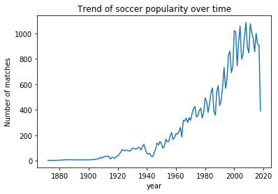

```python
#plotting trend of teams
df_football.groupby('year')['home_team'].count().plot(kind = 'line')
plt.title('Trend of soccer popularity over time')
plt.ylabel('Number of matches')
plt.show()
```

#### Observation:

Popularity of soccer increased gradually over time, having peak in 2008 with **1087** matches

### Which team scored the most goals in Soccer history ?

```python
#grouping teams and their scores
df_home_scores = df_football.iloc[:,np.r_[1,3]]
df_home_scores.columns = ['team','score']
df_away_scores = df_football.iloc[:,np.r_[2,4]]
df_away_scores.columns = ['team', 'score']
df_team_scores = df_home_scores.append(df_away_scores, ignore_index=True)
df_team_scores.groupby('team')['score'].sum().sort_values(ascending = False).head(10)
df_team_scores.groupby('team')['score'].sum().sort_values(ascending = False).head(10)
```

```
team
England           2147
Brazil            2095
Germany           2087
Sweden            1982
Hungary           1866
Argentina         1785
Netherlands       1580
Korea Republic    1474
Mexico            1448
France            1448
Name: score, dtype: int64
```

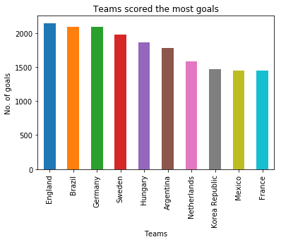

```python
df_team_scores.groupby('team')['score'].sum().sort_values(ascending = False).head(10).plot.bar()
plt.xlabel('Teams')
plt.ylabel('No. of goals')
plt.title('Teams scored the most goals')
plt.show()
```

### Top tournaments with most matches

```python
#grouping tournaments and their records
df_football.groupby('tournament')['home_team'].count().sort_values(ascending = False).head(10)
```

```
tournament
Friendly                                16475
FIFA World Cup qualification             7100
UEFA Euro qualification                  2332
African Cup of Nations qualification     1558
FIFA World Cup                            897
Copa América                              787
AFC Asian Cup qualification               724
African Cup of Nations                    638
CECAFA Cup                                620
CFU Caribbean Cup qualification           606
Name: home_team, dtype: int64
```

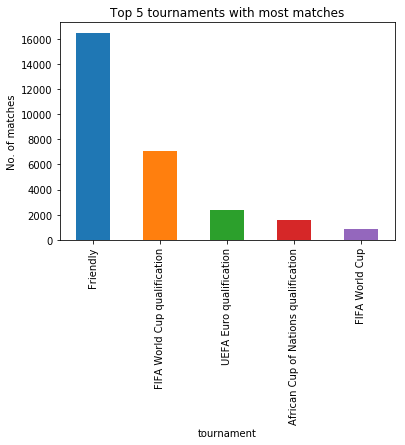

```python
df_football.groupby('tournament')['home_team'].count().sort_values(ascending = False).head(5).plot.bar()
plt.ylabel('No. of matches')
plt.title('Top 5 tournaments with most matches')
plt.show()
```

### Best team of all time

#### Answer:

**Brazil** is the best team with **610** wins out of **957** matches.

```python
total_matches =  pd.DataFrame(all_teams.groupby('teams')['teams'].count())
total_matches.rename(columns={'teams':'total_matches'}, inplace=True)
total_matches.reset_index(level=0, inplace=True)
total_matches.sort_values(by= 'total_matches', inplace= True, ascending = False)
total_matches.head()
```

|  | teams | total_matches |
| --- | --- | --- |
| 245 | Sweden | 998 |
| 75 | England | 982 |
| 33 | Brazil | 957 |
| 11 | Argentina | 957 |
| 92 | Germany | 933 |

```python
df_home_wins = df_football.groupby(['home_team','result'], as_index=False)['away_team'].count()
df_home_wins=df_home_wins.query( "result == 'home' or result == 'tie'")
df_home_wins_pivot = df_home_wins.pivot_table(index=['home_team'], columns='result')
df_home_wins_pivot.columns = df_home_wins_pivot.columns.droplevel().rename(None)
df_home_wins_pivot.reset_index(level=0, inplace=True)
df_home_wins_pivot.head()
```

|  | home_team | home | tie |
| --- | --- | --- | --- |
| 0 | Abkhazia | 8.0 | 4.0 |
| 1 | Afghanistan | 16.0 | 7.0 |
| 2 | Albania | 58.0 | 40.0 |
| 3 | Algeria | 154.0 | 69.0 |
| 4 | American Samoa | 3.0 | 1.0 |

```python
df_away_wins = df_football.groupby(['away_team','result'], as_index=False)['home_team'].count()
df_away_wins = df_away_wins.query( "result == 'away' or result == 'tie'")
df_away_wins_pivot = df_away_wins.pivot_table(index=['away_team'], columns='result')
df_away_wins_pivot.columns = df_away_wins_pivot.columns.droplevel().rename(None)
df_away_wins_pivot.reset_index(level=0, inplace=True)
df_away_wins_pivot.head()
```

|  | away_team | away | tie |
| --- | --- | --- | --- |
| 0 | Abkhazia | 2.0 | 4.0 |
| 1 | Afghanistan | 13.0 | 15.0 |
| 2 | Albania | 20.0 | 27.0 |
| 3 | Alderney | 2.0 | NaN |
| 4 | Algeria | 48.0 | 64.0 |

```python
df_wins_loses = pd.merge(df_home_wins_melted,df_away_wins_melted,how = 'inner', left_on = 'home_team', right_on = 'away_team')
df_wins_loses['victory'] = df_wins_loses['home'] + df_wins_loses['away']
df_wins_loses['tie'] = df_wins_loses['tie_x'] + df_wins_loses['tie_y']
df_wins_loses = pd.merge(df_wins_loses,total_matches,how = 'inner', left_on = 'home_team', right_on = 'teams')
df_wins_loses['lose'] = df_wins_loses['total_matches'] - (df_wins_loses['victory'] + df_wins_loses['tie'])
df_wins_loses.drop(['home', 'tie_x', 'away_team','away','tie_y','teams'], inplace=True, axis=1)
df_wins_loses.rename(columns={'home_team':'team'}, inplace=True)
df_wins_loses.sort_values(by=['victory'],ascending=False, inplace=True)
df_wins_loses.reset_index(level=0, inplace=True)
df_wins_loses.drop(['index'], inplace=True, axis=1)
df_wins_loses = df_wins_loses.fillna(0)
df_wins_loses['victory'] = df_wins_loses['victory'].astype(int)
df_wins_loses.head(10)
```

|  | team | victory | tie | total_matches | lose |
| --- | --- | --- | --- | --- | --- |
| 0 | Brazil | 610 | 192.0 | 957 | 155.0 |
| 1 | England | 557 | 239.0 | 982 | 186.0 |
| 2 | Germany | 546 | 191.0 | 933 | 196.0 |
| 3 | Argentina | 513 | 238.0 | 957 | 206.0 |
| 4 | Sweden | 490 | 219.0 | 998 | 289.0 |
| 5 | Korea Republic | 439 | 214.0 | 837 | 184.0 |
| 6 | Hungary | 427 | 201.0 | 912 | 284.0 |
| 7 | Mexico | 422 | 200.0 | 841 | 219.0 |
| 8 | Italy | 412 | 221.0 | 785 | 152.0 |
| 9 | France | 403 | 175.0 | 819 | 241.0 |

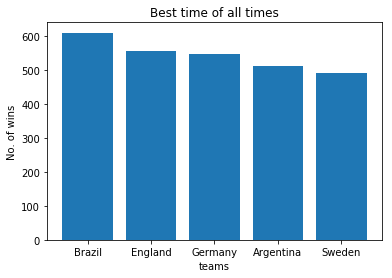

```python
#plotting teams and their wins
plt.bar(df_wins_loses['team'].head(n=5), df_wins_loses['victory'].head(n=5))
plt.xlabel('teams')
plt.ylabel('No. of wins')
plt.title('Best time of all times')
plt.show()
```

### Highest scoring Match in history

#### Answer:

It is match played between **Australia and American Samoa in FIFA World cup qualification round** in Australia, where Australia scored **31** goals while opposite team was not able to score any goal.

```python
#calculting total score of the game
df_football['total_score'] = df_football['home_score'] + df_football['away_score']
```

```python
df_football.sort_values(by = 'total_score', ascending=False).head(1)
```

|  | date | home_team | away_team | home_score | away_score | tournament | city | country | neutral | result | month | year | total_score |
| --- | --- | --- | --- | --- | --- | --- | --- | --- | --- | --- | --- | --- | --- |
| 23680 | 2001-04-11 | Australia | American Samoa | 31 | 0 | FIFA World Cup qualification | Coffs Harbour | Australia | False | home | Apr | 2001 | 31 |

### Which Month is most popular for soccer games?

#### Answer:

```python
#grouping data with months
df_football.groupby('month')['home_team'].count().sort_values(ascending = False)
```

```
month
Jun    5698
Oct    4311
Nov    3947
Sep    3943
Mar    3903
May    3186
Aug    2673
Jul    2660
Feb    2548
Apr    2514
Dec    2174
Jan    2112
Name: home_team, dtype: int64
```

## Model Building

This model will predict the result of game i.e **home , away or tie**

**Independent variable** - `home team`, `away team`, `tournament`, `country`, `month` and `neutral`

**Dependent variable / predicting** - `result`

```python
#creating dataset copy
df_football_copy = df_football.copy()
```

```python
#dsiplaying columns in dataframe
df_football_copy.columns
```

```
Index(['date', 'home_team', 'away_team', 'home_score', 'away_score',
       'tournament', 'city', 'country', 'neutral', 'result', 'month', 'year',
       'total_score'],
      dtype='object')
```

```python
#extracting the pridicting variable
y = df_football['result']
```

### Removing extra columns

```python
#droppin extra columns
df_football_copy.drop(['date','home_score','away_score','city','year','total_score','result'], inplace=True, axis=1)
df_football_copy.columns
```

```
Index(['home_team', 'away_team', 'tournament', 'country', 'neutral', 'month'], dtype='object')
```

### One-hot encoding

```python
#creating dummy variables
X = pd.get_dummies(df_football_copy)
```

### Splitting into train and test dataset

```python
#splitting dataset into test and train
X_train,X_test, y_train, y_test = train_test_split(X, y , test_size = 0.3, random_state = 5)
```

### Decision Tree

```python
#building model with decision tree algorithm
model = tree.DecisionTreeClassifier(random_state=1)
model.fit(X_train,y_train)
pred_y = model.predict(X_test)
print("accuracy:",round(accuracy_score(y_test, pred_y),2))
print(confusion_matrix(y_test, pred_y))
print("precision", precision_score(y_test, pred_y, average=None))
print("recall", recall_score(y_test, pred_y, average= None))
```

```
accuracy: 0.47
[[1456 1275  693]
 [1205 3576  969]
 [ 822 1294  611]]
precision [0.41803043 0.58193653 0.26880774]
recall [0.42523364 0.62191304 0.22405574]
```

### Random Forest

```python
#building model with random forest algorithm
model = RandomForestClassifier(random_state=1, max_depth=300)
model.fit(X_train,y_train)
pred_y = model.predict(X_test)
```

```python
#model scores
print("accuracy:",round(accuracy_score(y_test, pred_y),2))
print(confusion_matrix(y_test, pred_y))
print("precision", precision_score(y_test, pred_y, average=None))
print("recall", recall_score(y_test, pred_y, average= None))
```

[output not shown]

#### Optimising the model - k fold validation

```python
#optimising model with k-fold validation
randomforest_skfold_accuracy = []
skf = StratifiedKFold(n_splits=10, random_state=22)
for train_index,test_index in skf.split(X,y):

    #extrcting the test and training dataset
    X_train,X_test =  X.iloc[train_index], X.iloc[test_index]
    y_train, y_test = y[train_index], y[test_index]


    #loading the model
    model = RandomForestClassifier(random_state=1, max_depth=300)
    #fitting the model with training set
    model.fit(X_train, y_train)



    # predicting using the test
    pred_y = model.predict(X_test)
    randomforest_skfold_accuracy.append(round(accuracy_score(y_test,pred_y),2))
randomforest_mean_accuracy = np.mean(randomforest_skfold_accuracy)
print("Mean accuracy:",randomforest_mean_accuracy)
```

```
Mean accuracy: 0.483
```

```python
#print accuracy results of each iteration
print(randomforest_skfold_accuracy)
```

```
[0.47, 0.46, 0.47, 0.46, 0.49, 0.49, 0.5, 0.52, 0.48, 0.49]
```

```
                                            **End of Notebook**
```